# ANS 1 9891

**(a)**

$$log(p(x)) =log(\frac{1}{2\pi|\Sigma|^{1/2}} \exp\left(-\frac{1}{2}(x-\mu)^T \Sigma^{-1} (x-\mu)\right))$$

$$log(p(x))=-\frac{1}{2}(x-\mu)^T \Sigma^{-1} (x-\mu)-\log\!\bigl(2\pi |\Sigma|^{1/2}\bigr)$$

**$p(x)$=$p_0$ is a postive constant, so that means $log(p(x))$=$log(p_0)$**

$$-\frac{1}{2}(x-\mu)^T \Sigma^{-1} (x-\mu)-\log\!\bigl(2\pi |\Sigma|^{1/2}\bigr)=log(p_0)$$

$$(x-\mu)^T \Sigma^{-1} (x-\mu)=-2\log(\frac{p_0}{2\pi |\Sigma|^{-1/2}})$$

As we know $c>0$,

$$(x-\mu)^T \Sigma^{-1} (x-\mu)=c$$

**(b)**

$$(x-\mu)^T \Sigma^{-1} (x-\mu)$$

$V$ is orthogonal, $y = V^T(x-\mu)$ can be written as $yV = (x-\mu)$

$$(x-\mu)^T V \Lambda^{-1} V^T (x-\mu)$$

$$y^T\Lambda^{-1}y$$

$$\frac{y^2_1}{\lambda_1}+\frac{y^2_2}{\lambda_2}$$

because $\Lambda^{-1}=diag(\frac{1}{\lambda_1},\frac{1}{\lambda_2})$

**c)**

The transformed equation is $\frac{y_{1}^{2}}{\lambda _{1}}+\frac{y_{2}^{2}}{\lambda _{2}}=c$, which can be rewritten as:

$$\frac{y_{1}^{2}}{c\lambda _{1}}+\frac{y_{2}^{2}}{c\lambda _{2}}=1$$

This is the standard equation of an ellipse centered at the origin in the $(y_{1},y_{2})$ coordinate system, with semi-axes of lengths $a_{1}=\sqrt{c\lambda _{1}}$ and $a_{2}=\sqrt{c\lambda _{2}}$.

**d)**

Let $X \sim N(\mu, \Sigma)$ and

$$D^2(X) = (X-\mu)^T \Sigma^{-1} (X-\mu)$$

new random variable $Z=\Sigma ^{-1/2}(X-\mu )$

$$\mathbb{E}[Z]=\Sigma ^{-1/2}\mathbb{E}[X-\mu ]=\Sigma ^{-1/2}(0)=0$$

$$\text{Cov}(Z)=\mathbb{E}[ZZ^{T}]=\mathbb{E}[\Sigma ^{-1/2}(X-\mu )(X-\mu )^{T}(\Sigma ^{-1/2})^{T}]=\Sigma ^{-1/2}\mathbb{E}[(X-\mu )(X-\mu )^{T}]\Sigma ^{-1/2}=\Sigma ^{-1/2}\Sigma \Sigma ^{-1/2}=I$$

Thus, $Z\sim N(0,I)$, which means its components $Z_{1},Z_{2}$ are independent standard normal random variables.

let's express $D^{2}(X)$ in terms of $Z$.

$$(X-\mu )^{T}\Sigma ^{-1}(X-\mu )=(\Sigma ^{1/2}Z)^{T}\Sigma ^{-1}(\Sigma ^{1/2}Z)=Z^{T}(\Sigma ^{1/2})^{T}\Sigma ^{-1}\Sigma ^{1/2}Z$$

Since $\Sigma$ is symmetric, $\Sigma ^{1/2}$ is also symmetric, so $(\Sigma ^{1/2})^{T}=\Sigma ^{1/2}$.

$$D^{2}(X)=Z^{T}\Sigma ^{1/2}\Sigma ^{-1}\Sigma ^{1/2}Z=Z^{T}Z=Z_{1}^{2}+Z_{2}^{2}$$

The sum of squares of $k$ independent standard normal variables is a chi-square distribution with $k$ degrees of freedom. In this case, $k=2$, so $D^{2}(X)\sim \chi _{2}^{2}$

**e)**

The expression $\mathbb{P}\left(D^{2}(X)\le c_{\alpha }\right)=\alpha$ means that the probability of a random variable $X$ lying within the region defined by

$$\{{{(x-\mu)^{t}}\Sigma^{-1}(x-\mu)\le c_\alpha})\}$$

$$\mathbb{P}\left(D^{2}\le c_{\alpha }\right)=\alpha$$

So choosing $c_{\alpha }$ gives a level set that contains proportion $\alpha$ of the probability mass.

**f)**

$\textbf{K-Means:}$ algorithm for data clustering that uses the geometric distance between points to divide the data into K groups. We place each data point in the cluster where the mean is most closely located. The space is shaped like a Voronoi tessellation by the linear decision boundaries between clusters. The spherical shape and equal variance of the clusters are assumed here.

$\textbf{GMM/EM:}$ represents data as a combination of several Gaussian distributions. Each data point is associated with a posterior probability of belonging to each component. The shape of a cluster is determined by the covariance matrix $\Sigma_{k}$ of its corresponding Gaussian component. Since the equal-density contours of a Gaussian distribution form ellipses, the regions with the highest posterior probability for each component are inherently elliptical rather than spherical. This allows GMMs to flexibly capture clusters with different shapes and orientations.

```python
import sys
import random
import math
import numpy as np

random.seed(0)

# -------------------
# Data Set 1
# -------------------
X1 = []
for i in range(1000):
    theta = random.uniform(0, 2 * math.pi)
    radius = random.gauss(0, 0.2) + random.choice([1, 3])
    X1.append([radius * math.cos(theta), radius * math.sin(theta)])
X1 = np.array(X1)

# -------------------
# Data Set 2
# -------------------
X2 = []
for i in range(1000):
    theta = random.uniform(0, 2 * math.pi)
    radius = random.gauss(0, 0.1) + 2
    if theta < math.pi:
        X2.append([radius * math.cos(theta) - 1, radius * math.sin(theta)])
    else:
        X2.append([radius * math.cos(theta) + 1, radius * math.sin(theta)])
X2 = np.array(X2)

# -------------------
# Data Set 3
# -------------------
X3 = []
for i in range(1000):
    radius = random.gauss(0, 1)
    theta = random.uniform(0, 2 * math.pi)
    center = random.choice([[0, 1], [3, 3], [1, -3]])
    X3.append([radius * math.cos(theta) + center[0],
               radius * math.sin(theta) + center[1]])
X3 = np.array(X3)
```

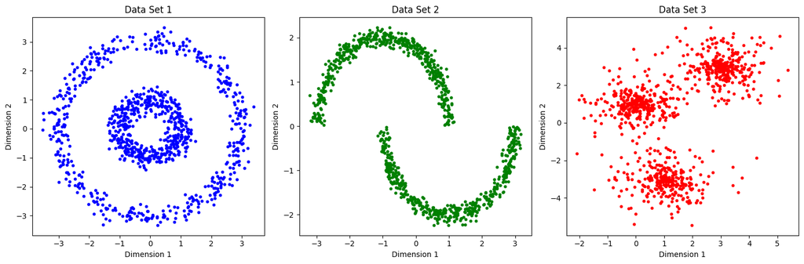

```python
import matplotlib.pyplot as plt

# Plot the three datasets side by side
fig, axes = plt.subplots(1, 3, figsize=(15, 5))

axes[0].scatter(X1[:, 0], X1[:, 1], s=10, c="blue")
axes[0].set_title("Data Set 1")
axes[0].set_xlabel("Dimension 1")
axes[0].set_ylabel("Dimension 2")

axes[1].scatter(X2[:, 0], X2[:, 1], s=10, c="green")
axes[1].set_title("Data Set 2")
axes[1].set_xlabel("Dimension 1")
axes[1].set_ylabel("Dimension 2")

axes[2].scatter(X3[:, 0], X3[:, 1], s=10, c="red")
axes[2].set_title("Data Set 3")
axes[2].set_xlabel("Dimension 1")
axes[2].set_ylabel("Dimension 2")

plt.tight_layout()
plt.show()
```

```python
## assume 'labels' is a list/array of group labels
## and X is the dataset being clustered
import matplotlib.pyplot as plt
import numpy as np

def plot_clusters(X, labels, title="Clustering Result"):
    """
    X: np.array of shape (n_samples, 2)
    labels: cluster labels (list or np.array)
    """
    unique_labels = np.unique(labels)
    colors = ['r', 'b', 'y', 'g', 'c', 'm', 'k', 'orange']

    for i, label in enumerate(unique_labels):
        points = X[labels == label]
        plt.scatter(points[:, 0], points[:, 1],
                    c=colors[i % len(colors)],
                    label=f"Cluster {label}", s=10)

    plt.xlabel("Dimension 1")
    plt.ylabel("Dimension 2")
    plt.title(title)
    plt.legend()
    plt.show()
```

```
--- Dataset 1 ---
```

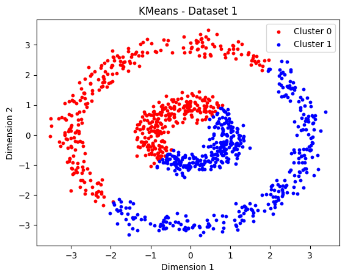

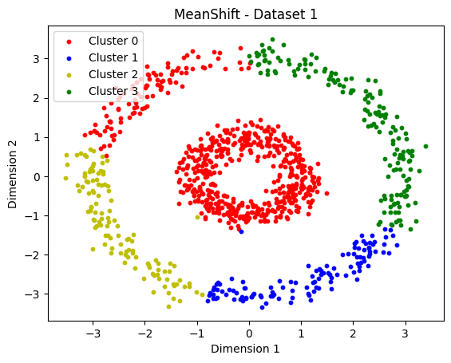

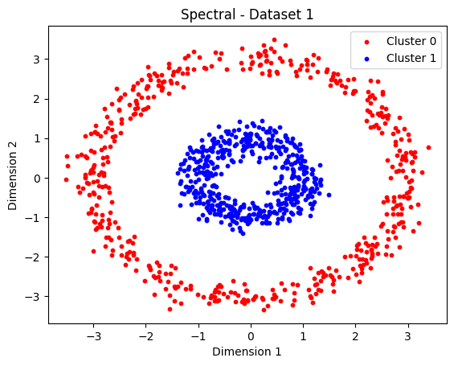

```
--- Dataset 2 ---
```

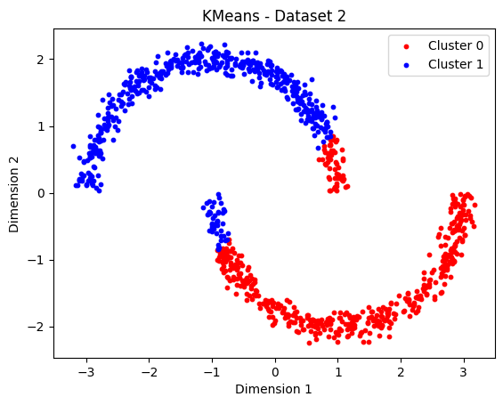

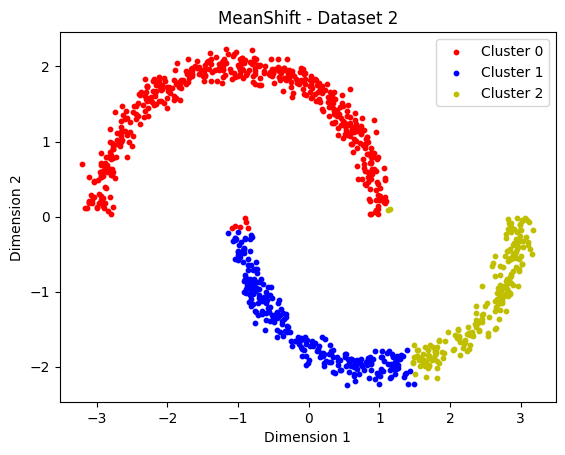

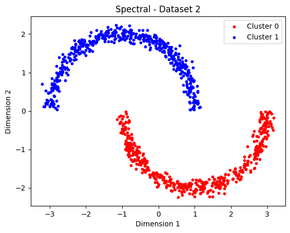

```
--- Dataset 3 ---
```

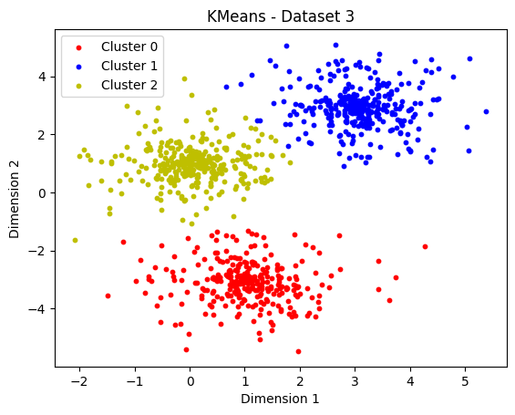

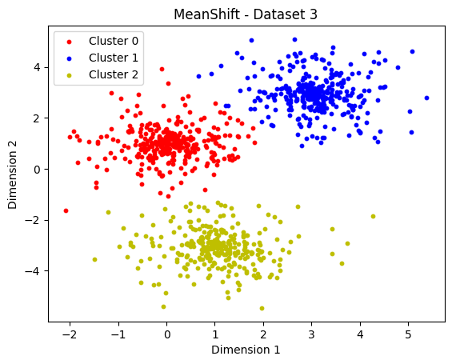

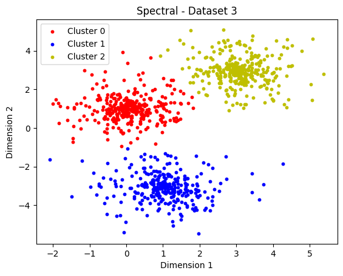

```python
from sklearn.cluster import MeanShift, KMeans, SpectralClustering
from sklearn.metrics import pairwise_distances

datasets = [(X1, 2), (X2, 2), (X3, 3)]  # (X, K)

for idx, (X, K) in enumerate(datasets, start=1):
    print(f"\n--- Dataset {idx} ---")

    # 1. KMeans
    kmeans = KMeans(n_clusters=K, random_state=0)
    kmeans_labels = kmeans.fit_predict(X)
    plot_clusters(X, kmeans_labels, title=f"KMeans - Dataset {idx}")

    # 2. MeanShift: bandwidth = 20% quantile of pairwise distances
    dists = pairwise_distances(X)
    dists = dists[np.triu_indices_from(dists, k=1)]  # take upper triangle
    bandwidth = np.quantile(dists, 0.2)
    meanshift = MeanShift(bandwidth=bandwidth)
    meanshift_labels = meanshift.fit_predict(X)
    plot_clusters(X, meanshift_labels, title=f"MeanShift - Dataset {idx}")

    # 3. Spectral Clustering
    spectral = SpectralClustering(n_clusters=K, affinity='nearest_neighbors', random_state=0)
    spectral_labels = spectral.fit_predict(X)
    plot_clusters(X, spectral_labels, title=f"Spectral - Dataset {idx}")
```